# Predicting emotion in words based on likert evaluation with repeated measures: a method comparison project

Daniel S. Granja

daniel.granja@etu.unige.ch

14 janvier, 2022

Abstract

Many researches in affective sciences use words to elicit emotions to study their impact on cognitive functions such as memory. It is important to control for the variability this elicitation has. In this project, we search for the best statistical method to control the emotional elicitation used in Riegel et al. (2020). It appears that the method that best fits is an ordinal logistic mixed-effect, with the best model having random slopes allowing fixed effects to vary for each emotion and considering the subjects’ repetition as a random effect. In conclusion, emotion isn’t felt by everyone the same way, and every participant evaluated multiple pairs of words. Plus, the ordinal scale of the evaluation created an ensemble of constraints that made us use sophisticated methods.

```r
#this is to check to see if package are installed and if not to install them or just load them if they are installed!
if(!require(pacman)) {install.packages("pacman")}

pacman::p_load(here, ggplot2, ordinal, ggfortify, GGally, grid,gridExtra, plyr, sjPlot, likert, vtable, brant, Hmisc, MASS, kableExtra, gtsummary, PResiduals)

#get relative path
path =here("DANIEL")

#load data

Raw_data <- read.csv2("Raw_data.csv")
```

## Introduction

### Context of the project

According to the American Psychological Association (APA), emotion is defined as “a complex reaction pattern, involving experiential, behavioral and physiological elements.”

It’s believed that the neurobiological systems sustaining high emotional arousal and memory are linked, especially through the adrenal stress hormones, itself mediated by the amygdala activity (McGaugh, 2013).

In the study the dataset came from, Riegel et al. (2020) used words to elicit emotions (disgust, fear or neutral). Each pair displayed the same emotion and when showed together they had to imagine an interaction between them, forcing the creation of a meaningful association. To be sure that the displayed words showed the correct emotion, affective ratings were asked as controls. Each participant had to rate each pair on a Likert scale (1 to 7) of disgust and fear.

In this project, we are going to use part of this dataset to analyse and compare three statistical methods. We will compare (a) a simple logistic ordinal regression, (b) a simple mixed-effect model only considering the subjects’ repetition as a random effect, and (c) a more complete mixed-effect model with random slopes allowing fixed effects to vary for each emotion. We follow the ‘Keep it maximal’ procedure from Barr et al. (2013) to find a model that best fits our data, considering how the emotion elicited in the word pairs and the gender impact the subjective ratings of disgust by the participants.

### Data description

Here is a description of the different variables:

- **Subjects**: the subject’s number in the experiment.
- **Wordpairs**: the word pairs presented.
- **Emotion**: the emotion elicited by the word pairs (disgust, fear or neutral).
- **Gender**: the gender of the subjects (man or woman).
- **Disgust**: a Likert scale (1 to 7) of the subjects’ emotional subjective feeling of disgust while judging the word pairs.

```r
#Creating a working dataset
#Giving nice names to variables

subjects<-Raw_data$code
wordpairs<-Raw_data$wordpair
emotion<-Raw_data$emotion
gender<-Raw_data$sex
disgust<-Raw_data$disgust
fear<-Raw_data$fear

#Creating a dataset
Data<-data.frame(subjects, wordpairs, emotion, gender, disgust)
```

```r
#Adapting the variables
Data$emotion<-as.factor(Data$emotion)
levels(Data$emotion) <- c("Disgust", "Fear","Neutral")
Data$gender<-as.factor(Data$gender)
levels(Data$gender) <- c("Women", "Men")
Data$disgust<-as.factor(Data$disgust)
```

## Data overview

### Structure

```r
str(Data)
```

```
'data.frame':   9349 obs. of  5 variables:
 $ subjects : chr  "sb0804" "sb0804" "sb0804" "sb0804" ...
 $ wordpairs: chr  "awersja - tytoniowy" "Å›cieki - oczyszczaÄ‡" "cygaro - cuchnÄ…cy" "Å›winia - szczecina" ...
 $ emotion  : Factor w/ 3 levels "Disgust","Fear",..: 1 1 1 1 1 1 1 1 1 1 ...
 $ gender   : Factor w/ 2 levels "Women","Men": 2 2 2 2 2 2 2 2 2 2 ...
 $ disgust  : Factor w/ 7 levels "1","2","3","4",..: 1 2 3 3 4 1 1 2 2 2 ...
```

### Summary

```r
# st(Data) # replacded by that so its nicer
Data[c("emotion", "gender", "disgust")] %>%  tbl_summary()  %>% modify_caption("**Summary statistics**") %>% bold_labels()
```

**Summary statistics**

| **Characteristic** | **N = 9,349**<sup>1</sup> |
| --- | --- |
| emotion |  |
| Disgust | 3,116 (33%) |
| Fear | 3,116 (33%) |
| Neutral | 3,117 (33%) |
| gender |  |
| Women | 4,496 (48%) |
| Men | 4,853 (52%) |
| disgust |  |
| 1 | 6,611 (71%) |
| 2 | 972 (10%) |
| 3 | 706 (7.6%) |
| 4 | 432 (4.6%) |
| 5 | 288 (3.1%) |
| 6 | 174 (1.9%) |
| 7 | 166 (1.8%) |

<sup>*1*</sup> n (%)

As one can see in this table, the distribution of emotion through the word pairs and the gender is equivalent. However, the distribution of the disgust response has a floor effect, more than 80% of it being 1 and 2.

## Visual exploration

```r
## Prepare data for plot <- **need to specify emotion$disgust + the other ratings**
Newdata<-data.frame(Data$emotion,Data$disgust)

df = prop.table(table(Newdata$Data.emotion, Newdata$Data.disgust), margin = 1)*100

#this is just ot make it fit into Likert
df = as.data.frame.matrix(df)
df$Item <- row.names(df)
rownames(df) = NULL
df = df[,c(8,1,2,3,4,5,6,7)]
colnames(df) = c("Item", "1 (low)","2","3","4","5","6","7 (high)")
```

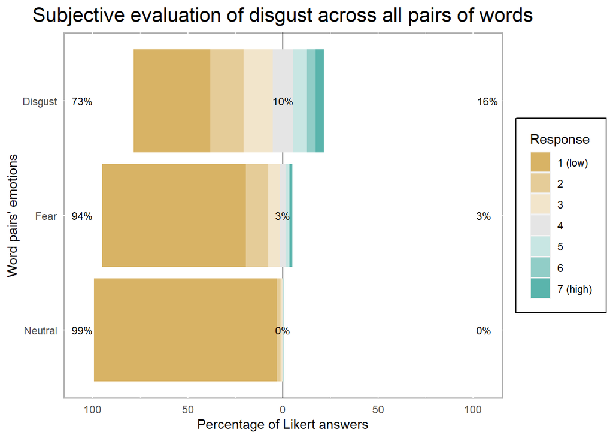

```r
# Pretty Plot
plot(likert(summary = df))+
  guides(fill = guide_legend(name="Subjective evaluation"))+
  labs(title = "Subjective evaluation of disgust across all pairs of words")+
  labs(y = "Percentage of Likert answers") +
  labs(x="Word pairs' emotions") +
  theme(plot.title = element_text(hjust = 0.5)) +
  theme(plot.title = element_text(size = rel(1.5))) +
  theme(legend.box.background = element_rect(), legend.box.margin = margin(6, 6, 6, 6), legend.position = "right")
```

This figure shows the distribution of the subjective evaluation of disgust across all pair of words, depending of the emotion elicited by the words. As one can see, there still is a floor effect, but it seems less strong for the disgust emotion, as one can expect since the emotion elicited corresponds to the emotion rated. However, this floor effect can be explained by the difficulty of identification of disgust (Yoder et al., 2016). Since it’s difficult to specifically recognize disgust, mixed to the small arousal of some word pairs, there is a possible existence of a bias in the ratings. Another representation including the gender can be found in Appendix 1.

## Modeling

Even if we have seen in our exploration that there seems to be a floor effect, we are going to do a diagnostic of a linear model to certify the unfit of this model to analyse our data.

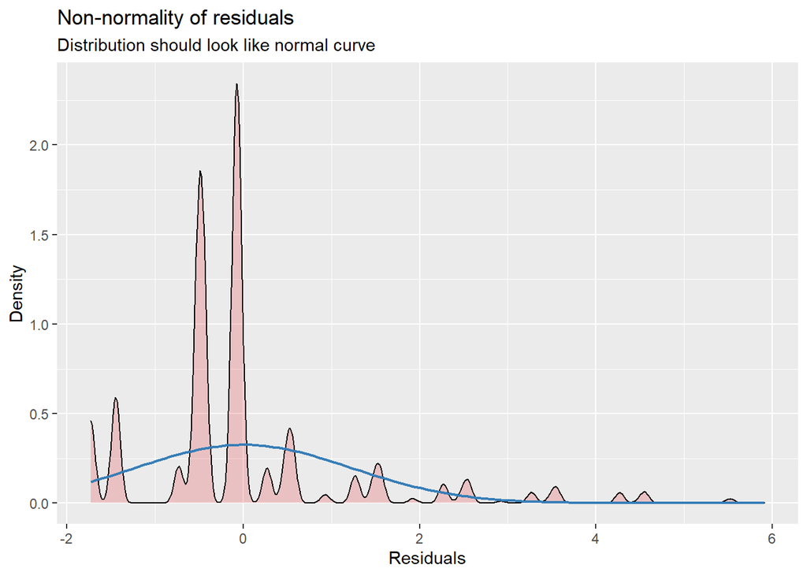

```r
sjPlot::plot_model(m0,type = "diag")[[3]]
```

As expected, the residuals distribution does not follow a normal curve. Therefore, we cannot do a classic linear regression to analyse this data. Alternative techniques have to be investigated. (Find more diagnostic graphs in the Appendix 2.)

Three possible methods are being tested: (a) a simple logistic ordinal regression, (b) a simple mixed-effect model only considering the subjects’ repetition as a random effect, and (c) a more complete mixed-effect model with random slopes allowing fixed effects to vary for each emotion.

```r
m1.2 = clm(disgust ~ emotion * gender, data = Data) #Model A
m2.2 = clmm(disgust ~ emotion * gender + (1|subjects), data = Data) #Model B
m3.2 = clmm(disgust ~ emotion * gender + (emotion | subjects), data = Data) #Model C
```

After computing the full model for each random structure, we can use the Akaike information criterion to estimate the prediction error of each model, and thereby their relative quality.

```r
a1<- extractAIC(m1.2)
a2<- extractAIC(m2.2)
a3<- extractAIC(m3.2)

c1<-cbind(a1,a2,a3)
r1<-c1[1,]
r2<-c1[2,]
c2<-as.data.frame(cbind(r1,r2))
rownames(c2) <- c("No random structure", "Simple random strucure","Full random structure")
colnames(c2) <- c("Equivalent degrees of freedom", "Akaike Information Criterion")
c2
```

```
##                        Equivalent degrees of freedom
## No random structure                               11
## Simple random strucure                            12
## Full random structure                             17
##                        Akaike Information Criterion
## No random structure                        17242.03
## Simple random strucure                     16204.65
## Full random structure                      16075.78
```

As shown in this table, we can conclude that the model that seems to fit the best our data is the full random structure model, a mixed-effect model with random slopes allowing fixed effects to vary for each emotion, as it has the smaller AIC, and more equivalent degrees of freedom.

We can test explicitly the random slope for emotions’ fixed effects to confirm the importance to have this complexity in the model.

```r
anova(m2.2, m3.2)
```

```
## Likelihood ratio tests of cumulative link models:
##
##      formula:                                          link: threshold:
## m2.2 disgust ~ emotion * gender + (1 | subjects)       logit flexible
## m3.2 disgust ~ emotion * gender + (emotion | subjects) logit flexible
##
##      no.par   AIC  logLik LR.stat df Pr(>Chisq)
## m2.2     12 16205 -8090.3
## m3.2     17 16076 -8020.9  138.87  5  < 2.2e-16 ***
## ---
## Signif. codes:  0 '***' 0.001 '**' 0.01 '*' 0.05 '.' 0.1 ' ' 1
```

This being done, we must now look for the best model using this random structure. According to our initial hypothesis, we want to know if there is an impact of the word pairs’ emotion and the gender on the subjective evaluation of disgust.

```r
#best model
#m3.2 = clmm(disgust ~ emotion * gender + (emotion | subjects), data = Data) #done above
m3.1 = clmm(disgust ~ emotion + gender + (emotion | subjects), data = Data)
m3.0 = clmm(disgust ~ emotion + (emotion | subjects), data = Data)


anova(m3.0, m3.1, m3.2, test='Chisq')
```

```
## Likelihood ratio tests of cumulative link models:
##
##      formula:                                          link: threshold:
## m3.0 disgust ~ emotion + (emotion | subjects)          logit flexible
## m3.1 disgust ~ emotion + gender + (emotion | subjects) logit flexible
## m3.2 disgust ~ emotion * gender + (emotion | subjects) logit flexible
##
##      no.par   AIC  logLik LR.stat df Pr(>Chisq)
## m3.0     14 16075 -8023.4
## m3.1     15 16077 -8023.4  0.0706  1    0.79040
## m3.2     17 16076 -8020.9  5.0360  2    0.08062 .
## ---
## Signif. codes:  0 '***' 0.001 '**' 0.01 '*' 0.05 '.' 0.1 ' ' 1
```

As shown in the test summary above, and also following the AIC estimate, the most parsimonious model is the model without gender effect.

### Statistical Inference

#### Model Summary

```r
summary(m3.0)
```

```
Cumulative Link Mixed Model fitted with the Laplace approximation

formula: disgust ~ emotion + (emotion | subjects)
data:    Data

 link  threshold nobs logLik   AIC      niter      max.grad cond.H
 logit flexible  9349 -8023.44 16074.89 1862(9330) 8.10e-03 4.9e+02

Random effects:
 Groups   Name           Variance Std.Dev. Corr
 subjects (Intercept)    0.9960   0.9980
          emotionFear    0.6443   0.8027   -0.050
          emotionNeutral 0.3974   0.6304   -0.699  0.405
Number of groups:  subjects 52

Coefficients:
               Estimate Std. Error z value Pr(>|z|)
emotionFear     -2.0596     0.1313  -15.68   <2e-16 ***
emotionNeutral  -3.9909     0.1497  -26.66   <2e-16 ***
---
Signif. codes:  0 '***' 0.001 '**' 0.01 '*' 0.05 '.' 0.1 ' ' 1

Threshold coefficients:
    Estimate Std. Error z value
1|2  -0.5346     0.1437  -3.721
2|3   0.3387     0.1435   2.359
3|4   1.1585     0.1445   8.018
4|5   1.8831     0.1467  12.834
5|6   2.6467     0.1515  17.466
6|7   3.4641     0.1619  21.402
```

Now that we have chosen our best model, we are going to take a deeper look at the estimates.

#### Regression summary table

```r
sjPlot::tab_model(m3.0, show.stat = TRUE, show.aic = T, show.reflvl = T, show.est = T, p.style = "stars")
```

disgust

Predictors

Odds Ratios

CI

Statistic

1|2

0.59 ***

0.44 – 0.78

-3.72

2|3

1.40 *

1.06 – 1.86

2.36

3|4

3.19 ***

2.40 – 4.23

8.02

4|5

6.57 ***

4.93 – 8.76

12.83

5|6

14.11 ***

10.48 – 18.99

17.47

6|7

31.95 ***

23.26 – 43.88

21.40

Disgust

*Reference*

Fear

0.13 ***

0.10 – 0.16

-15.68

Neutral

0.02 ***

0.01 – 0.02

-26.66

Random Effects

σ<sup>2</sup>

3.29

τ<sub>00</sub> <sub>subjects</sub>

1.00

τ<sub>11</sub> <sub>subjects.emotionFear</sub>

0.64

τ<sub>11</sub> <sub>subjects.emotionNeutral</sub>

0.40

ρ<sub>01</sub>

-0.05

-0.70

ICC

0.24

N <sub>subjects</sub>

52

Observations

9349

Marginal R<sup>2</sup> / Conditional R<sup>2</sup>

0.381 / 0.528

AIC

16074.887

- p<0.05 ** p<0.01 *** p<0.001

The effect of the emotion predictors of fear (OR = 0.13, 95% CI 0.10-0.16, p < 0.001) and neutral (OR = 0.02, 95% CI 0.01-0.02, p < 0.001) are different from disgust. The random slope for emotions’ fixed effects has been reported above.

Being the model that best fits the data doesn’t mean that it’s a good model, that is why we must check for the explained variance. We can see that the Conditional R<sup>2</sup> is 0.528, which means that 52.8% of the variance is explained by both the fixed and random factors.

### Model visualization

#### Plot estimates

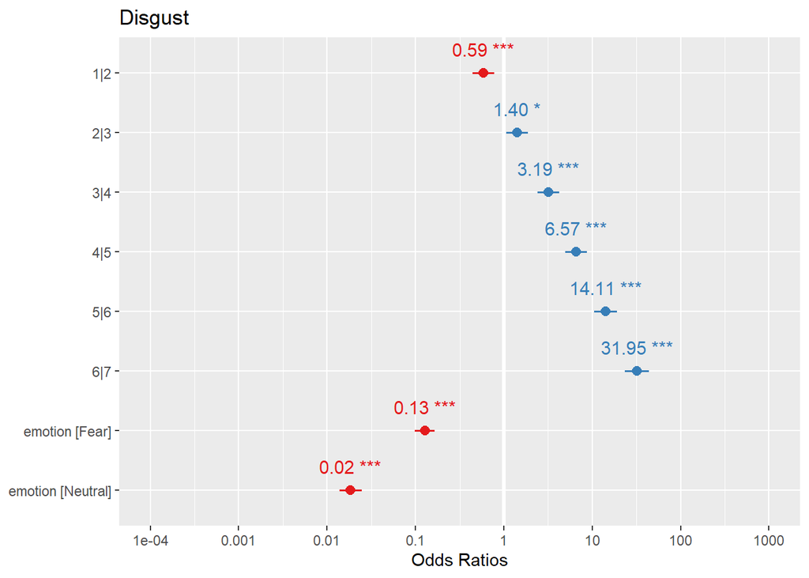

```r
plot_model(m3.0, show.values = T, value.offset = .4, title = "Disgust")
```

The model represented above shows how more a disgust evaluation is high, more the odds of the wordpairs’ eliciting disgust is high. It also shows that when the emotion elicited was not disgust, the odds of a high evaluation of disgust are low.

#### Plot marginal effects

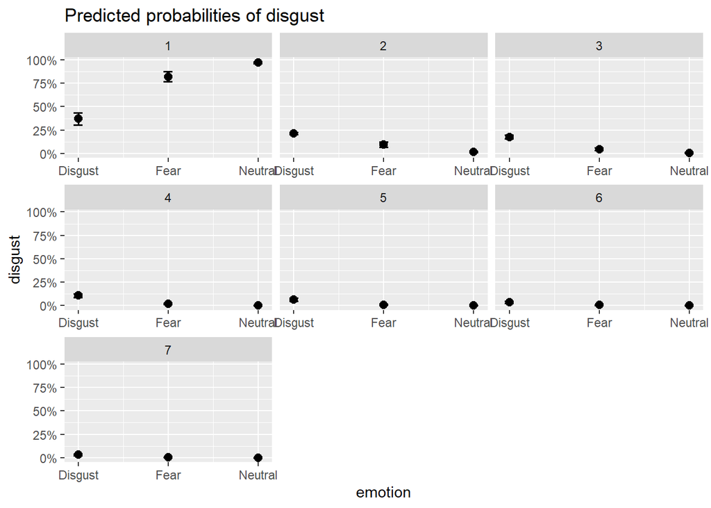

```r
plot_model(m3.0, type = "pred", terms = "emotion")
```

### Diagnostic of the model

Ordinal logistic regressions have four assumptions that need to be controled for when aplied:

- The dependent variables are ordered.
- One or more of the independent variables are either continuous, categorical or ordinal.
- No multi-collinearity.
- Proportional odds.

The two firsts are respected by the structure of our data (see Visual exploration). We must check for the two others.

#### Residual representation

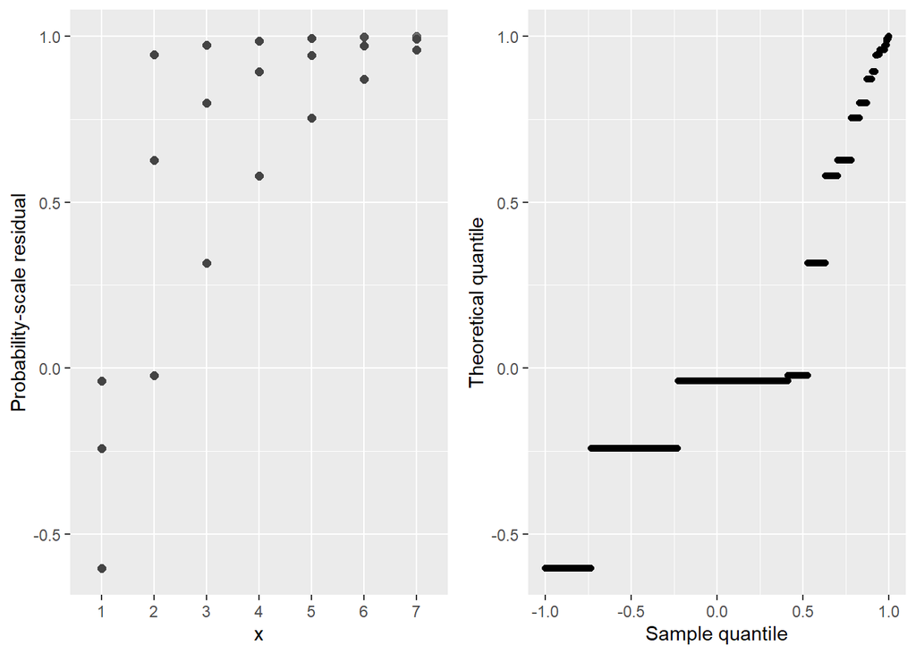

```r
# Residual-vs-covariate plot and Q-Q plot
m1.3<-polr(disgust ~ emotion, data = Data)
pres <- presid(m1.3)

p1 <- ggplot(data.frame(x = Data$disgust, y = pres), aes(x, y)) +
geom_point(color = "#444444", shape = 19, size = 2, alpha = 0.5) +
ylab("Probability-scale residual")
p2 <- ggplot(data.frame(y = pres), aes(sample = y)) +
stat_qq(distribution = qunif, dparams = list(min = -1, max = 1), alpha = 0.5) +
xlab("Sample quantile") +
ylab("Theoretical quantile")
grid.arrange(p1, p2, ncol = 2) # Figure 1
```

SBS residual plots for the ordinal logistic regression model. Left: Residual-vs-covariate plot. Right: Q-Q plot of the residuals.

#### No multi-collinearity

```r
Data[c("emotion", "gender", "disgust")] %>%  tbl_summary(by=emotion)  %>% modify_caption("**Summary statistics by emotion**") %>%
  add_p() %>% bold_labels()
```

**Summary statistics by emotion**

| **Characteristic** | **Disgust**, N = 3,116<sup>1</sup> | **Fear**, N = 3,116<sup>1</sup> | **Neutral**, N = 3,117<sup>1</sup> | **p-value**<sup>2</sup> |
| --- | --- | --- | --- | --- |
| gender |  |  |  | >0.9 |
| Women | 1,498 (48%) | 1,499 (48%) | 1,499 (48%) |  |
| Men | 1,618 (52%) | 1,617 (52%) | 1,618 (52%) |  |
| disgust |  |  |  | <0.001 |
| 1 | 1,256 (40%) | 2,357 (76%) | 2,998 (96%) |  |
| 2 | 543 (17%) | 369 (12%) | 60 (1.9%) |  |
| 3 | 482 (15%) | 192 (6.2%) | 32 (1.0%) |  |
| 4 | 326 (10%) | 92 (3.0%) | 14 (0.4%) |  |
| 5 | 229 (7.3%) | 52 (1.7%) | 7 (0.2%) |  |
| 6 | 148 (4.7%) | 22 (0.7%) | 4 (0.1%) |  |
| 7 | 132 (4.2%) | 32 (1.0%) | 2 (<0.1%) |  |

<sup>*1*</sup> n (%) <sup>*2*</sup> Pearson's Chi-squared test

We must check for any collinearity between our predictors. Our final model only has the wordpairs’ emotion as predictor, so there is no possible collinearity with other predictors. For the other models, we also included the gender. There is no multicollinearity between gender and emotion (χ²(2, N = 9349) = 0.0006, p > 0.05)

#### Proportional odds

To test for this assumption, we want to do a Brant Test. Unfortunately, we cannot do it directly to our mixed-effect model as the test is limited to ordinal logistic regression models. No alternative has been found during further investigations, even if the existence of a χ2 score test of the proportional odds assumptions has been noted, without further explanation (Schmidt, 2012).

However, we can test the model without the random effects and with only the emotion predictor as we may expect that these random effects do not influence the relationship between each pair of outcome groups.

```r
brant(m1.3)
```

```
--------------------------------------------
Test for    X2  df  probability
--------------------------------------------
Omnibus     11.21   10  0.34
emotionFear 10.06   5   0.07
emotionNeutral  1.13    5   0.95
--------------------------------------------

H0: Parallel Regression Assumption holds
```

The test tells us that the assumption is respected, which means that the assumptions for ordinal logistic regression are respected.

## Conclusion

The present data analysis was aimed to compare three statistical methods and to analyse how the emotion elicited in the word pairs and the gender impact the subjective ratings of disgust by the participants. As shown, the best method is the one that take in consideration the repetition of the subjects and the way each one of them express the emotion elicited.

For that, the mixed-effect model with random slopes allowing fixed effects to vary for each emotion and considering the subjects’ repetition as a random effect, but not including the gender was the best model tested.

In other words, gender doesn’t seem significative in the disgust evaluation, but it seems important to control for the way each subject evaluate the emotion.

Further investigation can be made with the fear evaluation of this dataset to support or reject this proposition. Fear is usually better recognized by the individuals, and the original dataset has a similar likert scale measuring the fear evaluation for each word pairs. If the same conclusion is found, it’s a good indicator that this model is the best to fit this kind of data.

Emotion isn’t felt by everyone the same way, and every participant evaluated multiple pairs of words. Plus, the ordinal scale of the evaluation created an ensemble of constraints that made us use more sophisticated methods than simple linear methods. However, that mean that the interpretation of these results aren’t very straight forward. The coefficients are scaled in terms of logs. Another way to interpret ordinal logistic regression models is to use odd ratios, which are more easy to understand.

## Bibliography

Barr, D. J., Levy, R., Scheepers, C., & Tily, H. J. (2013). Random effects structure for confirmatory hypothesis testing : Keep it maximal. Journal of memory and language, 68(3), 10.1016/j.jml.2012.11.001. https://doi.org/10.1016/j.jml.2012.11.001

Emotion – APA Dictionary of Psychology. (s. d.). Retrieved January 4, 2022 from https://dictionary.apa.org/emotion

McGaugh, J. L. (2013). Making lasting memories : Remembering the significant. Proceedings of the National Academy of Sciences, 110(2), 10402‑10407. https://doi.org/10.1073/pnas.1301209110

Riegel, M., Wierzba, M., Wypych, M., Ritchey, M., Jednoróg, K., Grabowska, A., Vuilleumier, P., & Marchewka, A. (2020). Distinct medial-temporal lobe mechanisms of encoding and amygdala-mediated memory reinstatement for disgust and fear (p. 825844). https://doi.org/10.1101/825844

Schmidt, J. (2012). Ordinal Response Mixed Models : A Case Study. 21. Retrieved January 4, 2022 from https://math.montana.edu/grad_students/writing-projects/2012/12schmidt.pdf

Schmidt, K., Patnaik, P., & Kensinger, E. A. (2011). Emotion’s influence on memory for spatial and temporal context. Cognition and Emotion, 25(2), 229‑243. https://doi.org/10.1080/02699931.2010.483123

Yoder, A. M., Widen, S. C., & Russell, J. A. (2016). The word disgust may refer to more than one emotion. Emotion, 16(3), 301‑308. https://doi.org/10.1037/emo0000118

## Appendix

### 1. Alternative graph

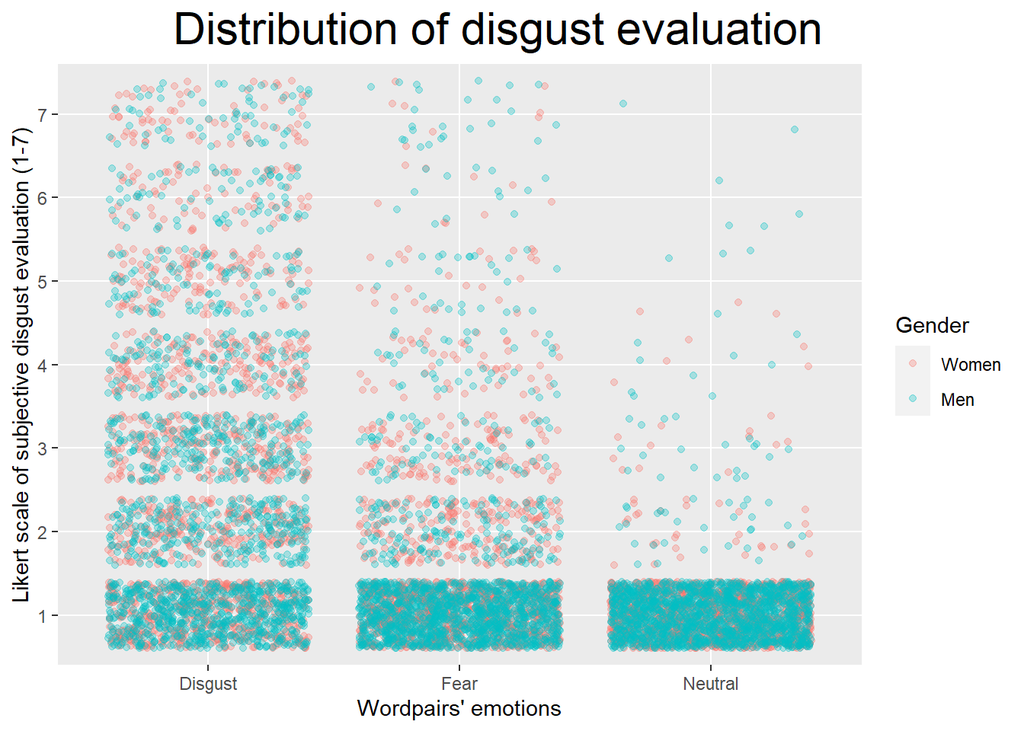

```r
##Disgust depending on emotion presented
ggplot(Data, aes(emotion,disgust,colour=gender))+geom_jitter(alpha=0.3)+
  labs(title = "Distribution of disgust evaluation", x = "Wordpairs' emotions", y = "Likert scale of subjective disgust evaluation (1-7)") + theme(plot.title = element_text(hjust = 0.75)) + labs(colour = "Gender")+ theme(plot.title = element_text(size = rel(2)))
```

### 2. Linear model diagnostics

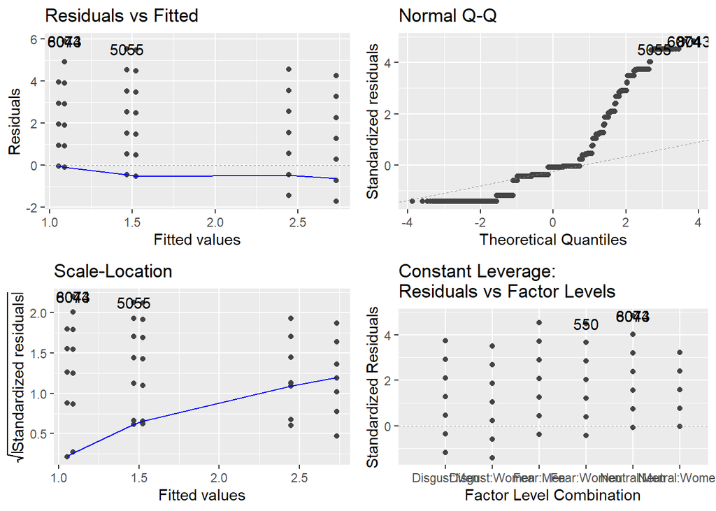

```r
autoplot(m0)
```

### 3. Package Info

```
  - gridExtra (version 2.3; Baptiste Auguie, 2017)
  - GGally (version 2.1.2; Barret Schloerke et al., 2021)
  - brant (version 0.3.0; Benjamin Schlegel and Marco Steenbergen, 2020)
  - ordinal (version 2019.12.10; Christensen, 2019)
  - xtable (version 1.8.4; David Dahl et al., 2019)
  - Hmisc (version 4.6.0; Frank E Harrell Jr, 2021)
  - ggplot2 (version 3.3.5; Wickham. ggplot2: Elegant Graphics for Data Analysis. Springer-Verlag New York, 2016.)
  - plyr (version 1.8.6; Hadley Wickham, 2011)
  - kableExtra (version 1.3.4; Hao Zhu, 2021)
  - likert (version 1.3.5; Jason Bryer and Kimberly Speerschneider, 2016)
  - here (version 1.0.1; Kirill Müller, 2020)
  - PResiduals (version 1.0.1; Liu Q et al., 2020)
  - sjPlot (version 2.8.10; Lüdecke D, 2021)
  - vtable (version 1.3.3; Nick Huntington-Klein, 2021)
  - R (version 4.1.2; R Core Team, 2021)
  - pacman (version 0.5.1; Rinker et al., 2017)
  - lattice (version 0.20.45; Sarkar, Deepayan, 2008)
  - gtsummary (version 1.5.0; Sjoberg DD, Whiting K, Curry M, Lavery JA, Larmarange Reproducible summary tables with the gtsummary package. The R Journal 2021;13:570–80. https://doi.org/10.32614/RJ-2021-053.)
  - survival (version 3.2.13; Therneau T, 2021)
  - MASS (version 7.3.54; Venables et al., 2002)
  - ggfortify (version 0.4.13; Yuan Tang et al., 2016)
  - Formula (version 1.2.4; Zeileis A, Croissant Y, 2010)
```